# PRAKRIKUM 4 Proses MA, AR dan ARMA

Naa’ila Nur Musyaffa

2026-09-22

# PROSES MA (2)

## 1. Pembangkitan MA (2) secara manual

```r
set.seed(123)

n <- 300
wn <- rnorm(n)

ma2 <- c(1:n)

ma2[1] <- wn[1]
ma2[2] <- wn[2] + 0.4*wn[1]

for (i in 3:n) {
  ma2[i] <- wn[i] + 0.4*wn[i-1] + 0.6*wn[i-2]
}

ma2
```

```
##   [1] -0.560475647 -0.454367748  1.130351930  0.555885223  1.092716080
##   [6]  1.809085116  1.224514842 -0.051655760 -0.916327622 -1.479439852
##  [11]  0.633705298  0.582049364  1.279146060  0.486879592 -0.271105178
##  [16]  1.630986312  0.879111052 -0.695329083  0.213419326 -1.372219341
##  [21] -0.836126728 -0.928779242 -1.753888638 -1.270077957 -1.532198429
##  [26] -2.374043755 -0.211913841 -0.523528051 -0.574115463  0.890584017
##  [31]  0.245108028  0.627803158  1.032975601  1.059140862  1.709909873
##  [36]  1.544152779  1.322322404  0.572839503  0.001623244 -0.540003093
##  [41] -1.030472978 -0.714082670 -1.765387450  1.538047058  1.316306573
##  [46]  0.661449795 -0.127351070 -1.301674438  0.351572076 -0.051376231
##  [51]  0.687949958  0.022759210  0.097701949  1.334326048  0.295947654
##  [56]  2.247323581 -1.077627154  0.874994991 -0.571551939  0.616251516
##  [61]  0.540328657 -0.220902719 -0.306353075 -1.453252408 -1.679145810
##  [66] -0.736333079 -0.073453501  0.414405323  1.212395026  2.450794209
##  [71]  0.882363189 -1.275530531 -0.212547725 -1.692406678 -0.368245807
```

[output cut: 45 more lines]

## 2. Pembangkitan MA (2) dengan arima.sim()

```r
ma2_sim <- arima.sim(
  list(order = c(0,0,2), ma = c(0.4,0.6)),
  n = 300
)

ma2_sim
```

```
## Time Series:
## Start = 1
## End = 300
## Frequency = 1
##   [1] -1.668759603 -1.879542142 -1.421288067 -0.475192608 -2.144034549
##   [6] -0.394996262  0.112940921  2.659432297  2.858210627  2.499789572
##  [11] -0.643314898 -0.838134009 -1.628687379  0.201801295 -0.035489647
##  [16] -0.878802820  1.117573456  0.829976398  1.612648214  1.859915494
##  [21] -0.709072680  0.856175749 -1.061848830  0.871072750 -0.101071172
##  [26]  1.018879244  1.552208727  0.921273564  1.821785242 -0.777036526
##  [31] -0.586442872  0.517515514  0.552112393 -0.989737004 -1.958493796
##  [36] -1.977729689 -0.032955473  0.123959897  1.102901812  1.147550413
##  [41]  2.429169463  1.299841891  0.973057684 -1.740420082 -0.633156493
##  [46] -1.584061436 -1.143153050 -0.912620099  0.358574931 -1.694714958
##  [51] -0.615412779 -1.249923525 -1.102920229  0.046602285  0.009066556
```

[output cut: 49 more lines]

## 3. Plot Time Series

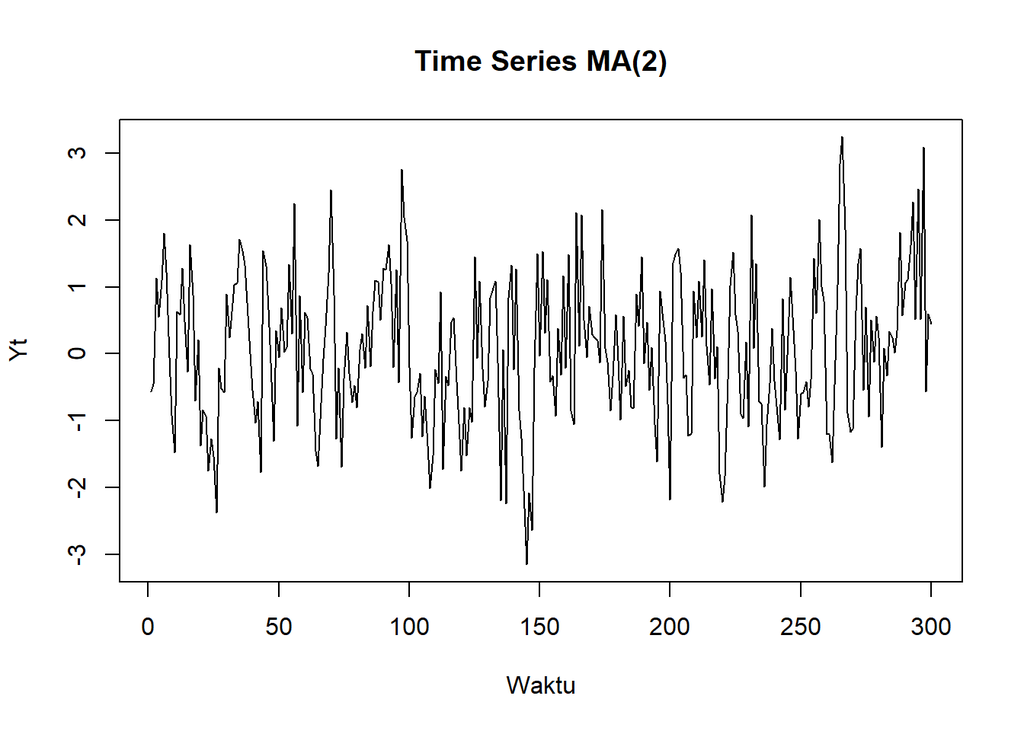

```r
ts.plot(ma2,
        main = "Time Series MA(2)",
        ylab = "Yt",
        xlab = "Waktu")
```

Plot deret waktu menunjukkan bahwa data sudah bersifat stasioner, karena fluktuasi data bergerak secara acak di sekitar rata-rata nol tanpa membentuk pola tren maupun musiman.

## 4. Plot ACF

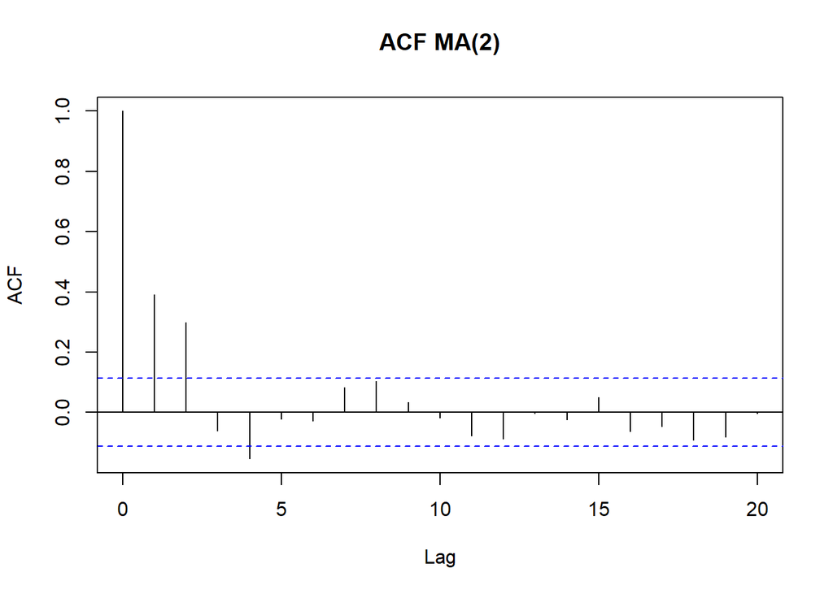

```r
acf(ma2,
    lag.max = 20,
    main = "ACF MA(2)")
```

## 5. Plot PACF

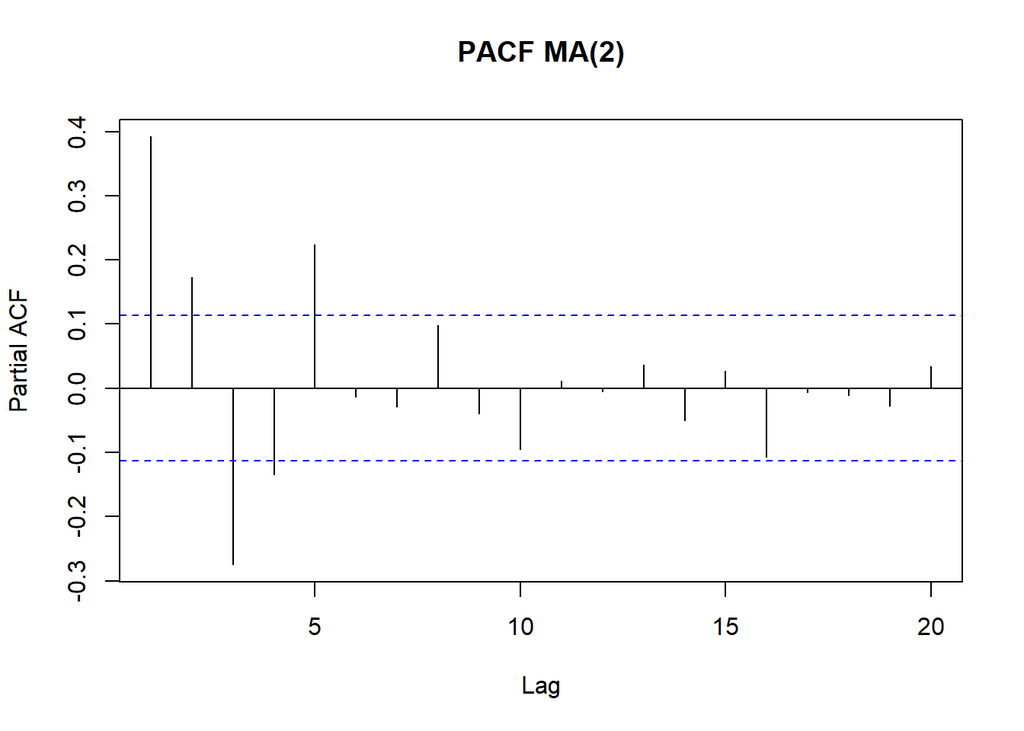

```r
pacf(ma2,
     lag.max = 20,
     main = "PACF MA(2)")
```

Plot PACF menunjukkan pola meluruh secara perlahan (tails off) menuju nol seiring bertambahnya lag, sehingga menguatkan identifikasi bahwa model yang terbentuk adalah MA(2).

## 6. Plot EACF

```r
TSA::eacf(ma2)
```

```
## AR/MA
##   0 1 2 3 4 5 6 7 8 9 10 11 12 13
## 0 x x o x o o o o o o o  o  o  o
## 1 x x x x o o o o o o o  o  o  o
## 2 x x o x o o o o o o o  o  o  o
## 3 x x o o x o o o o o o  o  o  o
## 4 x x x o x o o o o o o  o  o  o
## 5 o x x x x o o o o o o  o  o  o
## 6 x o x x x o o o o o o  o  o  o
## 7 x x o x x o o o o o o  o  o  o
```

## 7. Scatterploy Yt dengan Yt-1

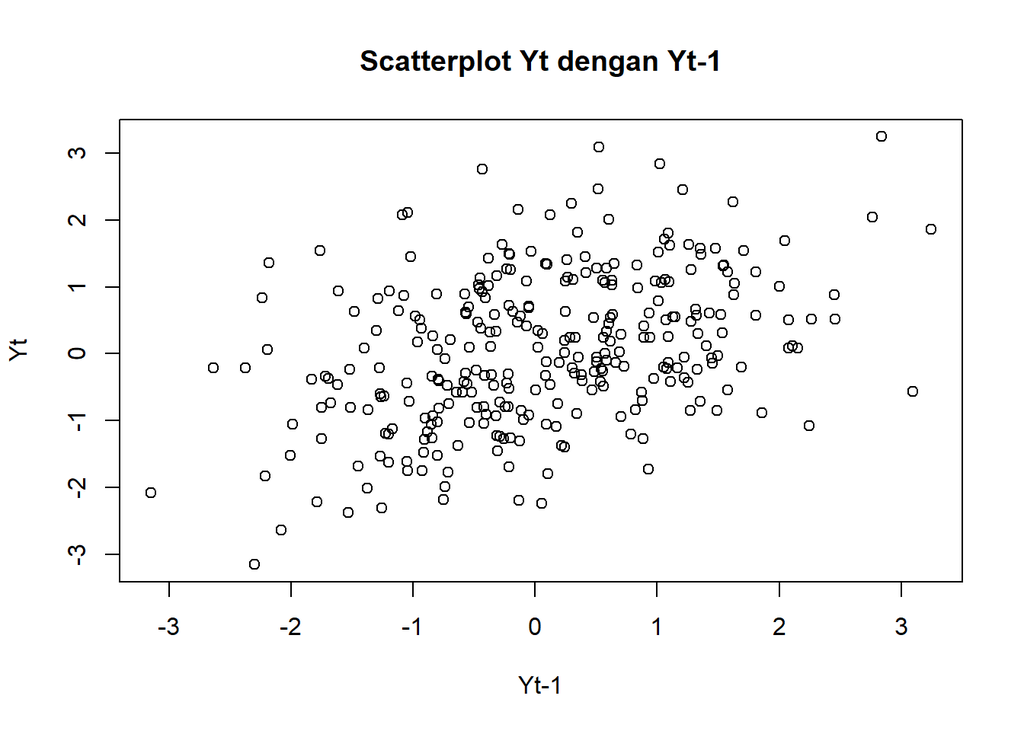

```r
yt_ma <- ma2[-1]
yt_1_ma <- ma2[-300]

plot(y = yt_ma,
     x = yt_1_ma,
     main = "Scatterplot Yt dengan Yt-1",
     xlab = "Yt-1",
     ylab = "Yt")
```

```r
cor(yt_ma, yt_1_ma)
```

```
## [1] 0.3921143
```

Scatterplot antara $Y_t$ dan lag ke-1 ($Y_{t-1}$) menunjukkan adanya pola linier positif yang lumayan jelas, mengindikasikan bahwa terdapat hubungan autokorelasi positif yang cukup kuat pada lag 1.

## 8. Scatterplot Yt dengan Yt-2

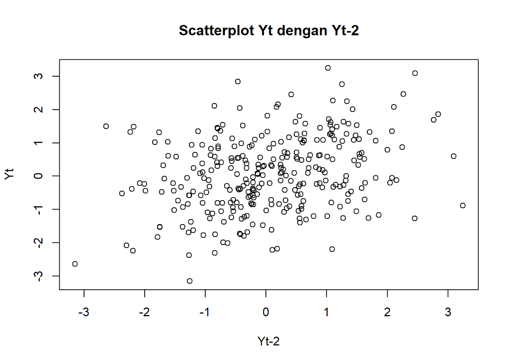

```r
yt_ma2 <- ma2[-c(1,2)]
yt_2_ma <- ma2[-c(299,300)]

plot(y = yt_ma2,
     x = yt_2_ma,
     main = "Scatterplot Yt dengan Yt-2",
     xlab = "Yt-2",
     ylab = "Yt")
```

```r
cor(yt_ma2, yt_2_ma)
```

```
## [1] 0.2998406
```

Scatterplot antara $Y_t$ dan lag ke-2 ($Y_{t-2}$) masih memperlihatkan pola hubungan linier positif, meskipun sebaran titik-titiknya mulai sedikit lebih renggang dibandingkan lag 1.

## 9. Scatterplot dengan Yt-3

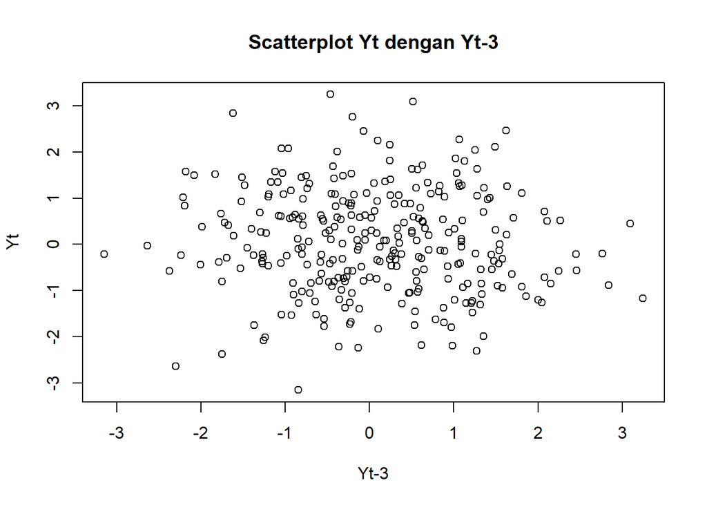

```r
yt_ma3 <- ma2[-c(1,2,3)]
yt_3_ma <- ma2[-c(298,299,300)]

plot(y = yt_ma3,
     x = yt_3_ma,
     main = "Scatterplot Yt dengan Yt-3",
     xlab = "Yt-3",
     ylab = "Yt")
```

```r
cor(yt_ma3, yt_3_ma)
```

```
## [1] -0.06107144
```

Scatterplot antara $Y_t$ dan lag ke-3 ($Y_{t-3}$) membentuk sebaran titik yang acak membulat tanpa pola linier, yang menandakan sudah tidak ada hubungan autokorelasi antara $Y_t$ dengan $Y_{t-3}$.

## 10. Autokorelasi Data Bangkitan

```r
acf(ma2,
    lag.max = 3,
    plot = FALSE)$acf[2:4]
```

```
## [1]  0.39182775  0.29938692 -0.06085596
```

## 11. Autokorelasi Secara Teoritis

```r
theta1 <- 0.4
theta2 <- 0.6

rho1 <- theta1*(1 + theta2) /
        (1 + theta1^2 + theta2^2)

rho2 <- theta2 /
        (1 + theta1^2 + theta2^2)

rho3 <- 0

rho1
```

```
## [1] 0.4210526
```

```r
rho2
```

```
## [1] 0.3947368
```

```r
rho3
```

```
## [1] 0
```

Hasil perhitungan autokorelasi sampel/bangkitan pada lag 1, 2, dan 3 menghasilkan nilai masing-masing sebesar 0.392, 0.299, dan -0.061, yang nilainya cukup mendekati perhitungan autokorelasi secara teoritis dengan nilai 0.421, 0.395, dan 0.

# PROSES AR(2)

## 1. Pembangkitan AR(2) secara manual

```r
set.seed(123)

n <- 300
wn <- rnorm(n)

ar2 <- c(1:n)

ar2[1] <- wn[1]
ar2[2] <- wn[2] + 0.5*ar2[1]

for (i in 3:n) {
  ar2[i] <- wn[i] + 0.5*ar2[i-1] + 0.2*ar2[i-2]
}

ar2
```

```
##   [1] -0.5604756466 -0.5104153128  1.1914055285  0.5641280931  0.6496328874
##   [6]  2.1527070492  1.6671963081 -0.0009216707 -0.3538744256 -0.6227835171
##  [11]  0.8419151538  0.6562147005  0.8972618316  0.6905565719 -0.0311104825
##  [16]  1.9094692099  1.4463629867 -0.8615418213  0.5598575883 -0.3651709779
##  [21] -1.1384376773 -0.8602279489 -1.6838059582 -1.7428397982 -1.8332203586
##  [26] -2.9518714497 -1.0047927520 -0.9393975481 -1.8087942615  0.1615382807
##  [31]  0.1454745095 -0.1900265721  0.8292072769  1.2547318116  1.6147884428
##  [36]  1.7469808378  1.7503657610  1.1626673375  0.6254441572  0.1647845451
##  [41] -0.4872258749 -0.4185733065 -1.5721281798  1.2991772141  1.5431249694
##  [46] -0.0917106557 -0.1401151692 -0.5550550694  0.4744145498  0.0428271946
##  [51]  0.3696150212  0.1648261942  0.1134656440  1.4583003449  0.5260723156
##  [56]  2.0711668312 -0.4079549255  0.7948696531  0.4396980853  0.5947645420
##  [61]  0.7649613708 -0.0008898593 -0.1806600391 -1.1090833745 -1.6624649216
##  [66] -0.7495204943 -0.2590434528 -0.2264215985  0.7572479780  2.3834243549
##  [71]  0.8521306070 -1.4064187011  0.4729552953 -0.7540068552 -0.9704209850
```

[output cut: 45 more lines]

## 2. Pembangkitan AR(2) dengan arima.sim()

```r
ar2_sim <- arima.sim(
  list(order = c(2,0,0), ar = c(0.5,0.2)),
  n = 300
)

ar2_sim
```

```
## Time Series:
## Start = 1
## End = 300
## Frequency = 1
##   [1]  0.85676868  0.35722100  0.98292495  1.89842429  1.15308723  1.97378711
##   [7]  0.02907696 -0.31230854  1.36887884  0.99936568 -1.27876421 -1.80354642
##  [13] -1.35830707 -0.17408341 -0.46058638  0.35907760  1.04642690  2.26608380
##  [19]  1.39834401  1.10040686 -0.92336513 -0.14227360 -0.82765988 -1.41629424
##  [25] -1.05358533  0.20489166 -2.10101972 -1.43681082 -1.02197207 -1.69155577
##  [31] -0.71626936 -0.28501591 -0.31879799 -2.68230037  1.16654836 -0.15848515
##  [37]  0.80526038  0.64469965  1.50807514  1.70063694  0.94214033  1.18936533
##  [43] -0.16229810  1.01364702  0.01332555  2.62616554 -0.33530102 -0.10640464
##  [49]  0.70511734  0.84141029 -0.02775243 -0.84237490 -0.28226223 -0.32391351
##  [55] -2.00869044 -1.03457685 -0.72879620 -0.39658707 -1.39906982 -0.30271905
##  [61]  0.94739665  0.86939092 -0.51141368 -0.51747413 -0.01491618 -0.75799855
```

[output cut: 39 more lines]

## 3. Plot Time Series

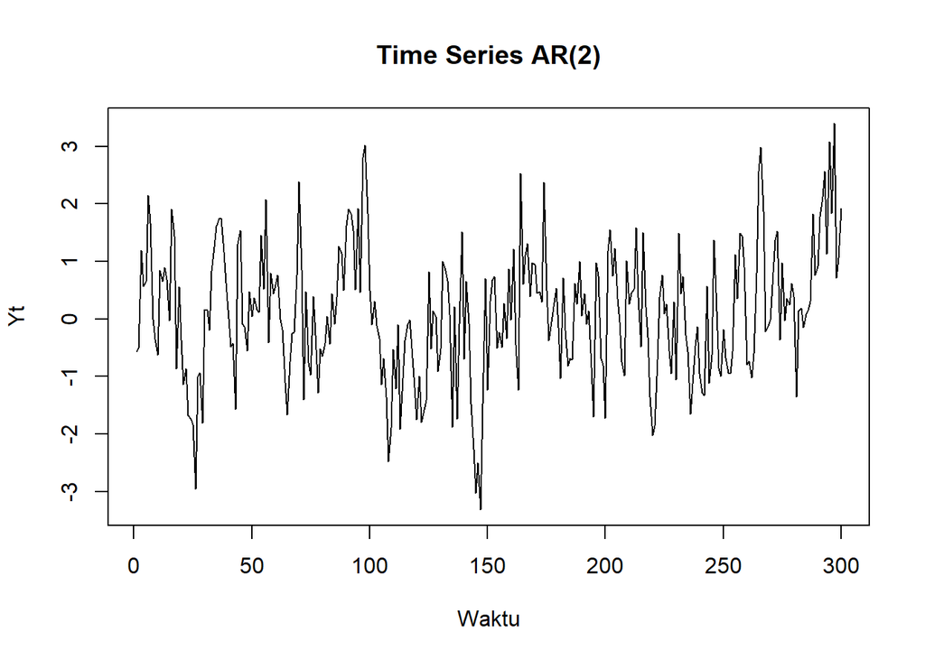

```r
ts.plot(ar2,
        main = "Time Series AR(2)",
        ylab = "Yt",
        xlab = "Waktu")
```

Plot deret waktu menunjukkan fluktuasi data bergerak secara acak di sekitar rata-rata nol tanpa adanya tren atau pola musiman, yang menandakan bahwa proses AR(2) ini sudah bersifat stasioner.

## 4. Plot ACF

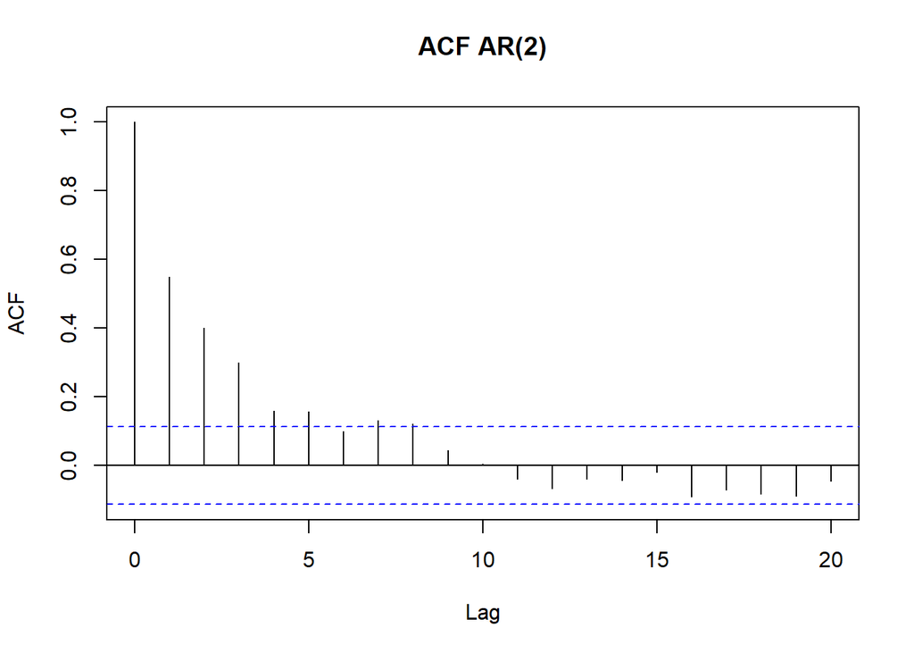

```r
acf(ar2,
    lag.max = 20,
    main = "ACF AR(2)")
```

Plot ACF memperlihatkan pola meluruh secara perlahan (tails off) mendekati nol seiring bertambahnya lag, yang menjadi salah satu indikator utama dari model Autoregressive (AR).

## 5. Plot PACF

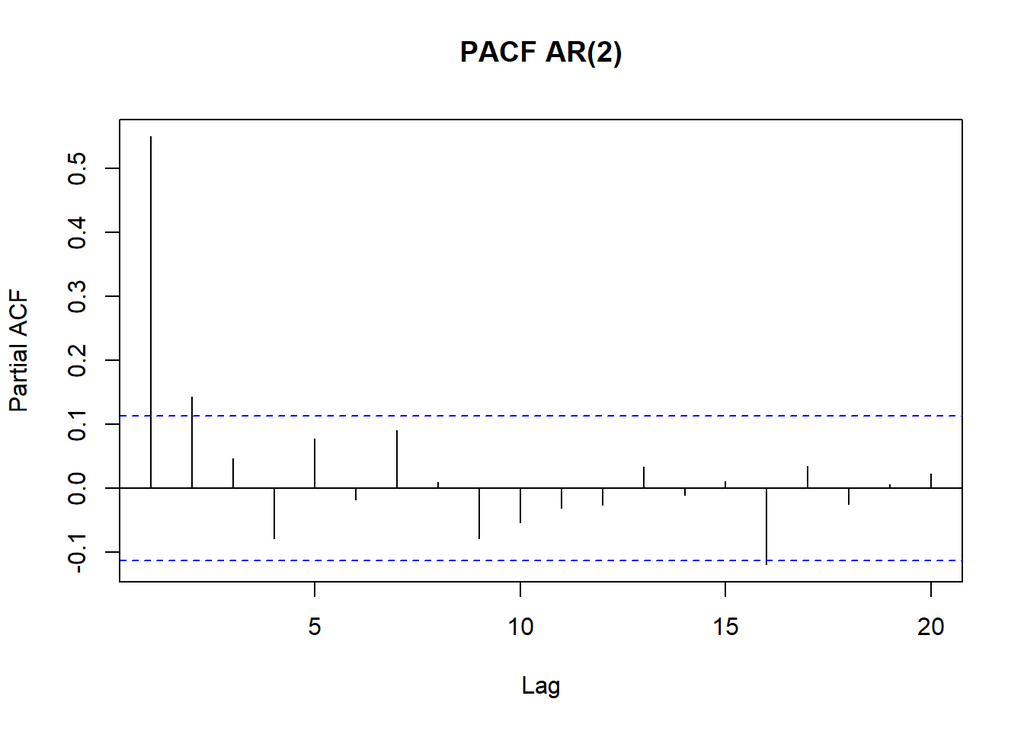

```r
pacf(ar2,
     lag.max = 20,
     main = "PACF AR(2)")
```

Plot PACF mengalami cut off tepat setelah lag 2, di mana hanya nilai pada lag 1 dan lag 2 yang signifikan melewati garis batas kepercayaan, yang secara spesifik mengidentifikasi model orde 2 atau AR(2).

## 6. Plot EACF

```r
TSA::eacf(ar2)
```

```
## AR/MA
##   0 1 2 3 4 5 6 7 8 9 10 11 12 13
## 0 x x x x x o x x o o o  o  o  o
## 1 x o o x o o o o o o o  o  o  o
## 2 x o o o o o o o o o o  o  o  o
## 3 x o o o o o o o o o o  o  o  o
## 4 x o o o o o o o o o o  o  o  o
## 5 x x o o o o o o o o o  o  o  o
## 6 x x o x x o o o o o o  o  o  o
## 7 x x o x x o x o o o o  o  o  o
```

## 7. Scatterplot Yt dengan Yt-1

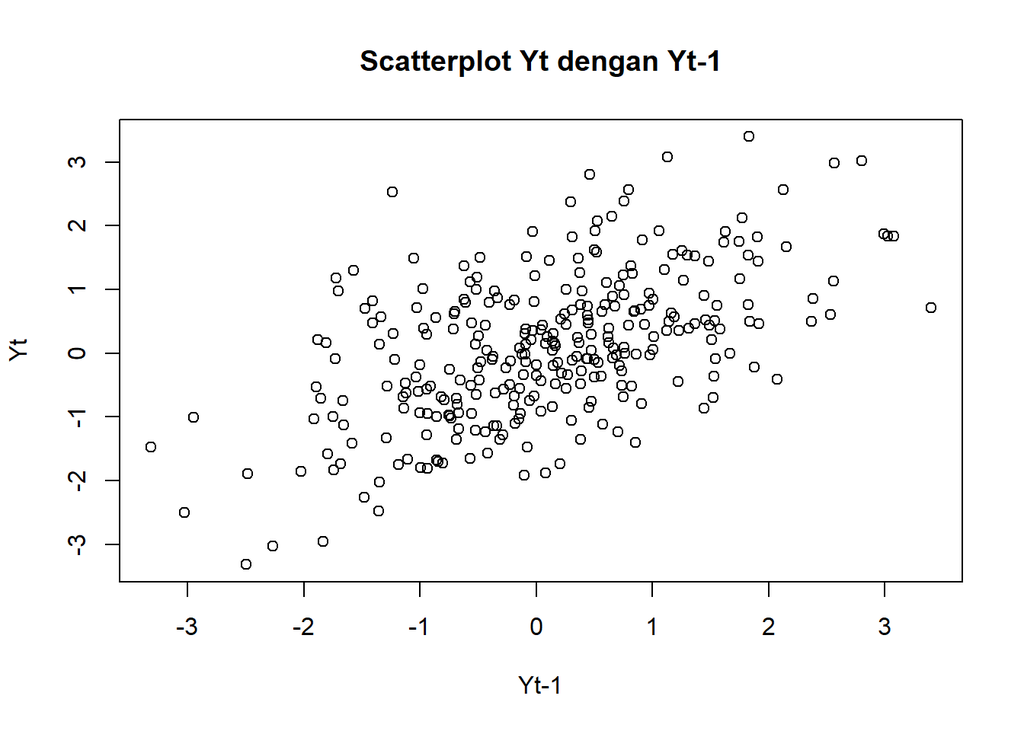

```r
# Yt
yt_ar <- ar2[-1]

# Yt-1
yt_1_ar <- ar2[-300]

plot(y = yt_ar,
     x = yt_1_ar,
     main = "Scatterplot Yt dengan Yt-1",
     xlab = "Yt-1",
     ylab = "Yt")
```

```r
cor(yt_ar, yt_1_ar)
```

```
## [1] 0.5520533
```

Scatterplot antara $Y_t$ dan $Y_{t-1}$ membentuk pola linier positif yang cukup kuat dan rapat, menunjukkan adanya autokorelasi linier yang signifikan pada lag 1.

## 8. Scatterplot Yt dengan Yt-2

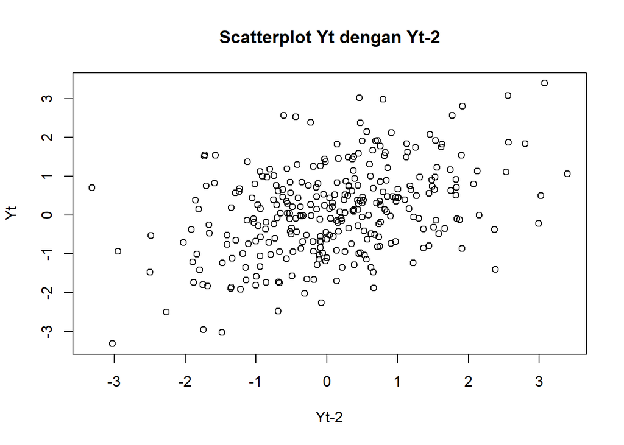

```r
# Yt
yt_ar2 <- ar2[-c(1,2)]

# Yt-2
yt_2_ar <- ar2[-c(299,300)]

plot(y = yt_ar2,
     x = yt_2_ar,
     main = "Scatterplot Yt dengan Yt-2",
     xlab = "Yt-2",
     ylab = "Yt")
```

```r
cor(yt_ar2, yt_2_ar)
```

```
## [1] 0.4040146
```

Scatterplot antara $Y_t$ dan $Y_{t-2}$ masih memperlihatkan pola linier positif, namun sebaran titik-titiknya sedikit lebih renggang dibandingkan pada lag 1.

## 9. Scatterplot Yt dengan YT-3

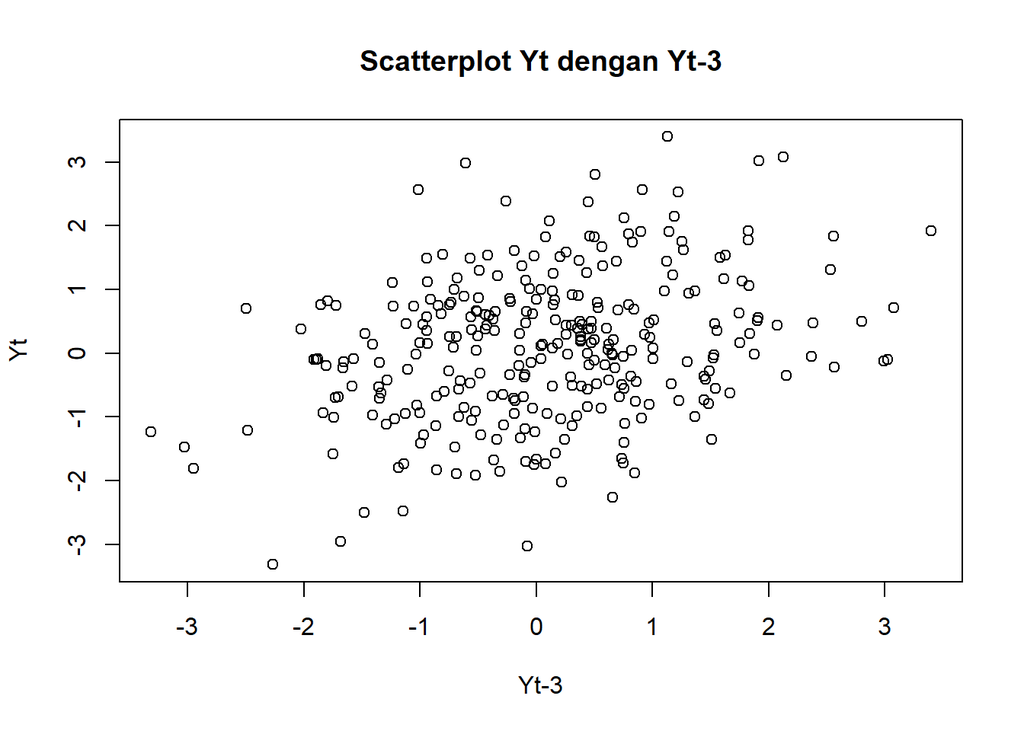

```r
# Yt
yt_ar3 <- ar2[-c(1,2,3)]

# Yt-3
yt_3_ar <- ar2[-c(298,299,300)]

plot(y = yt_ar3,
     x = yt_3_ar,
     main = "Scatterplot Yt dengan Yt-3",
     xlab = "Yt-3",
     ylab = "Yt")
```

```r
cor(yt_ar3, yt_3_ar)
```

```
## [1] 0.3018909
```

Scatterplot antara $Y_t$ dan $Y_{t-3}$ menunjukkan sebaran titik yang makin menyebar dan membulat, menandakan hubungan linier antar-lag yang makin melemah.

## 10. Autokorelasi Hasil Bangkitan

```r
acf(ar2,
    lag.max = 3,
    plot = FALSE)$acf[2:4]
```

```
## [1] 0.5493663 0.4013445 0.2993006
```

## 11. Autokorelasi secara teoritis

```r
phi1 <- 0.5
phi2 <- 0.2

rho1 <- phi1 / (1 - phi2)

rho2 <- phi1*rho1 + phi2

rho3 <- phi1*rho2 + phi2*rho1

rho1
```

```
## [1] 0.625
```

```r
rho2
```

```
## [1] 0.5125
```

```r
rho3
```

```
## [1] 0.38125
```

Nilai autokorelasi sampel/bangkitan pada lag 1, 2, dan 3 adalah sebesar 0.549, 0.401, dan 0.299, yang polanya sejalan dan mendekati nilai autokorelasi teoritisnya yaitu 0.625, 0.513, dan 0.381.

# PROSES ARMA(2,2)

# 1. Pembangkitan ARMA(2,2) secara manual

```r
set.seed(123)

n <- 300
wn <- rnorm(n)

phi1 <- 0.5
phi2 <- 0.2
theta1 <- 0.4
theta2 <- 0.6

arma22 <- c(1:n)

arma22[1] <- wn[1]
arma22[2] <- phi1*arma22[1] + wn[2] + theta1*wn[1]

for (i in 3:n) {
  arma22[i] <- phi1*arma22[i-1] +
               phi2*arma22[i-2] +
               wn[i] +
               theta1*wn[i-1] +
               theta2*wn[i-2]
}

arma22
```

```
##   [1] -0.560475647 -0.734605571  0.650954015  0.734441117  1.590127442
##   [6]  2.751037060  2.918058860  1.957581082  0.646074691 -0.764886290
##  [11]  0.380477092  0.619310652  1.664896804  1.443190125  0.783469245
##  [16]  2.311358960  2.191484381  0.862684899  1.083058652 -0.658153035
##  [21] -0.948591515 -1.534705606 -2.710959744 -2.932498951 -3.540639853
##  [26] -4.730863472 -3.285473547 -3.112437519 -2.787428932 -1.125617953
##  [31] -0.875186735 -0.034913800  0.840481354  1.472398779  2.614205534
##  [36]  3.145735302  3.418031162  2.911002145  2.140730549  1.112562610
##  [41] -0.046045563 -0.514592929 -2.031893027  0.419181958  1.119518947
##  [46]  1.305045661  0.749075550 -0.666127530  0.168323420 -0.100440027
##  [51]  0.671394629  0.338368519  0.401165134  1.602582319  1.177471840
##  [56]  3.156575964  0.736155196  1.874387782  0.512872991  1.247565568
##  [61]  1.266686039  0.661953414  0.277960840 -1.181881306 -2.214494295
##  [66] -2.079956488 -1.556330603 -0.779751276  0.511253267  2.550470587
##  [71]  2.259849136  0.364488155  0.421666179 -1.408675958 -0.988250550
```

[output cut: 45 more lines]

## 2. Pembangkitan dengan arima.sim()

```r
arma22_sim <- arima.sim(
  list(order = c(2,0,2),
       ar = c(0.5,0.2),
       ma = c(0.4,0.6)),
  n = 300
)

arma22_sim
```

```
## Time Series:
## Start = 1
## End = 300
## Frequency = 1
##   [1]  1.640891524  2.506702150  2.502802944  3.574527144  1.510787635
##   [6]  0.883856374  1.261601228  1.359684282 -0.057574618 -1.715344249
##  [11] -2.846916737 -1.799482691 -1.345164796  0.070422876  0.913728892
##  [16]  2.900118484  2.932646912  3.019404837  0.355811719  0.148630334
##  [21] -1.438583925 -1.832718945 -2.116696356 -1.066317037 -2.651212748
##  [26] -2.154282560 -2.857307354 -2.962430418 -2.006074395 -1.586456726
##  [31] -0.862565667 -2.980828884 -0.097650403 -1.301245893  1.441795439
##  [36]  0.871712790  2.249111283  2.690686834  2.527240222  2.586603649
##  [41]  0.878732244  1.662346994  0.321405512  3.239683980  0.723160535
##  [46]  1.335174274  0.461374872  1.059614437  0.731882091 -0.348629697
##  [51] -0.635863645 -0.942243339 -2.307613178 -2.032401132 -2.347841202
```

[output cut: 49 more lines]

## 3. Plot time series

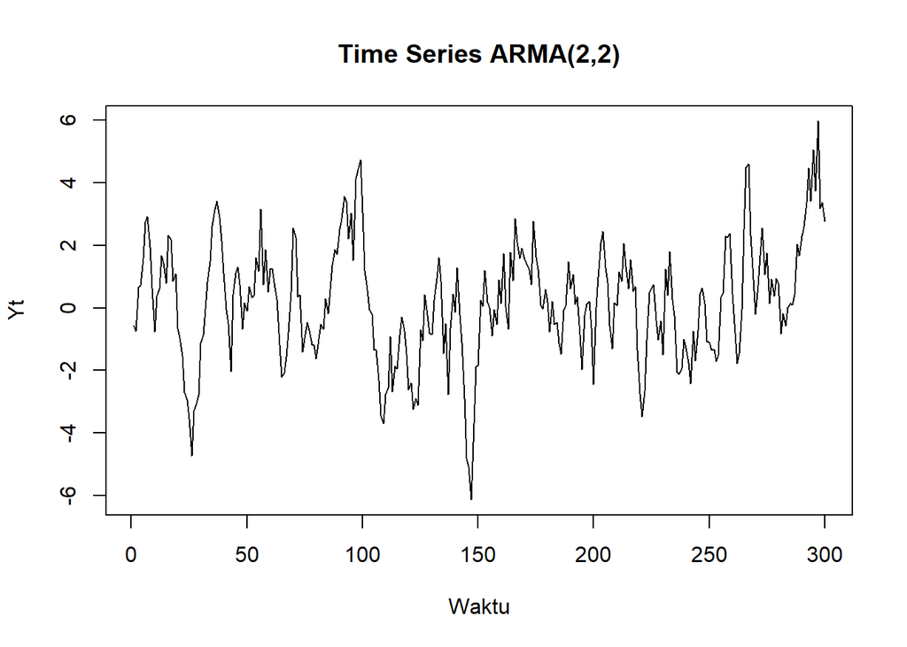

```r
ts.plot(arma22,
        main = "Time Series ARMA(2,2)",
        ylab = "Yt",
        xlab = "Waktu")
```

Plot deret waktu menunjukkan fluktuasi data yang bergerak secara acak di sekitar rata-rata nol tanpa adanya pola tren (naik/turun) maupun musiman yang eksplisit, menandakan bahwa proses $\text{ARMA}(2,2)$ ini bersifat stasioner dalam rata-rata.

## 4. Plot ACF

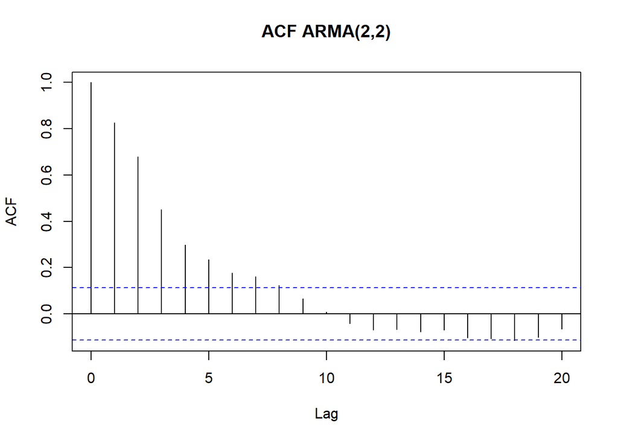

```r
acf(arma22,
    lag.max = 20,
    main = "ACF ARMA(2,2)")
```

Plot ACF meluruh secara perlahan (tails off) mendekati nol seiring bertambahnya lag, yang mencerminkan karakteristik gabungan komponen Autoregressive (AR) dan Moving Average (MA).

## 5. Plot PACF

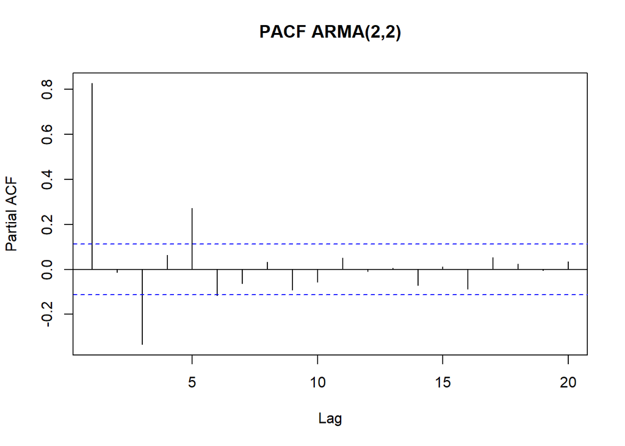

```r
pacf(arma22,
     lag.max = 20,
     main = "PACF ARMA(2,2)")
```

Plot PACF juga meluruh secara perlahan (tails off) mendekati nol tanpa berhenti secara mendadak (cut off), yang semakin mengonfirmasi karakteristik khas dari proses campuran ARMA.

## 6. Plot EACF

```r
TSA::eacf(arma22)
```

```
## AR/MA
##   0 1 2 3 4 5 6 7 8 9 10 11 12 13
## 0 x x x x x x x x o o o  o  o  o
## 1 o x o x o o o o o o o  o  o  o
## 2 o x o x o o o o o o o  o  o  o
## 3 x x o x o o o x o o o  o  o  o
## 4 x x o x o o o x o o o  o  o  o
## 5 x x o x x o o o o o o  o  o  o
## 6 x x o x o o o o o o o  o  o  o
## 7 x o x x x o o o o o o  o  o  o
```

## 7. Scatterplot Yt dengan Yt-1

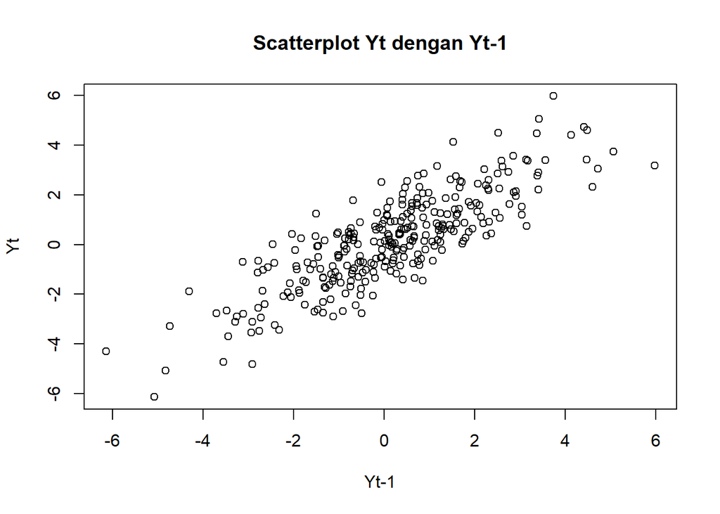

```r
yt_arma <- arma22[-1]
yt_1_arma <- arma22[-300]

plot(y = yt_arma,
     x = yt_1_arma,
     main = "Scatterplot Yt dengan Yt-1",
     xlab = "Yt-1",
     ylab = "Yt")
```

```r
cor(yt_arma, yt_1_arma)
```

```
## [1] 0.8290537
```

Scatterplot antara $Y_t$ dan $Y_{t-1}$ membentuk pola linier positif yang sangat rapat dan kuat, menunjukkan adanya autokorelasi positif yang tinggi pada lag 1.

## 8. Scatterplot Yt dengan Yt-2

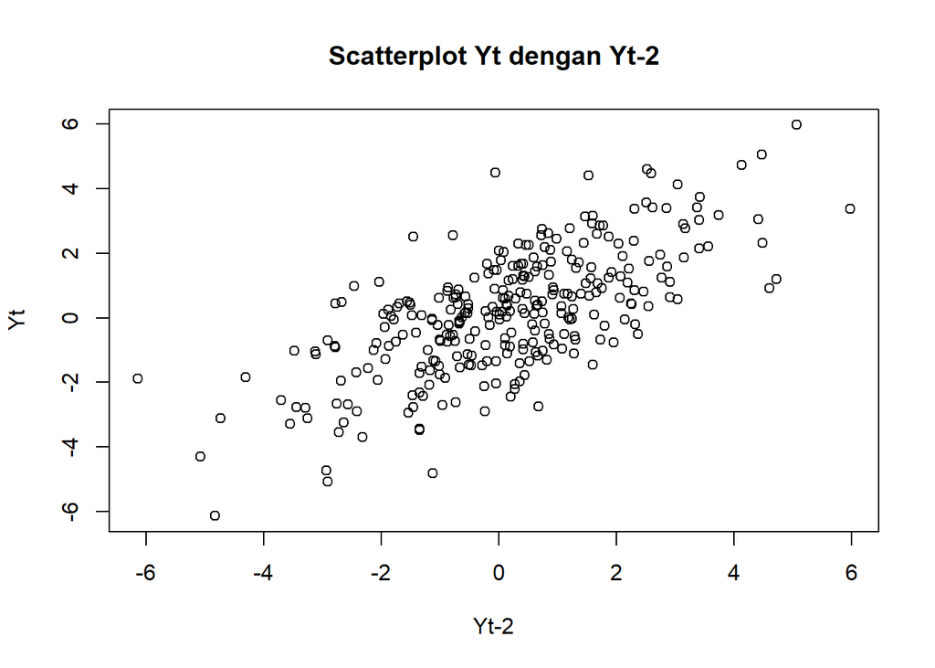

```r
yt_arma2 <- arma22[-c(1,2)]
yt_2_arma <- arma22[-c(299,300)]

plot(y = yt_arma2,
     x = yt_2_arma,
     main = "Scatterplot Yt dengan Yt-2",
     xlab = "Yt-2",
     ylab = "Yt")
```

```r
cor(yt_arma2, yt_2_arma)
```

```
## [1] 0.6845635
```

Scatterplot antara $Y_t$ dan $Y_{t-2}$ masih menunjukkan pola linier positif yang jelas, namun tingkat kerapatan titik-titiknya sedikit berkurang dibandingkan pada lag 1.

## 9. Scatterplot Yt dengan Yt-3

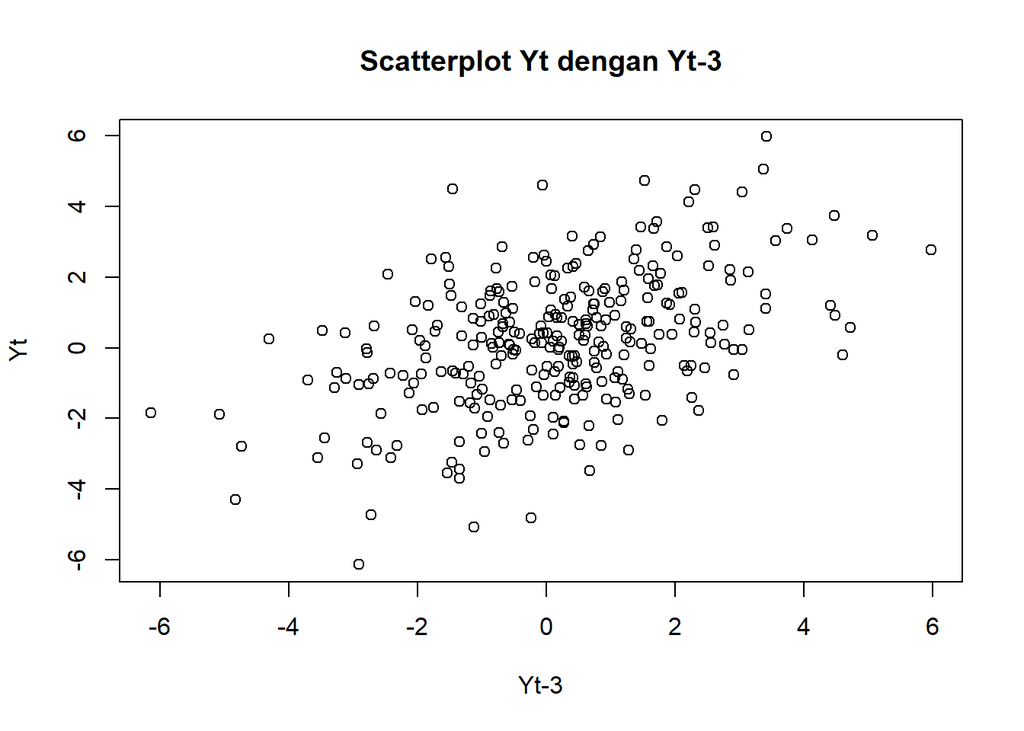

```r
yt_arma3 <- arma22[-c(1,2,3)]
yt_3_arma <- arma22[-c(298,299,300)]

plot(y = yt_arma3,
     x = yt_3_arma,
     main = "Scatterplot Yt dengan Yt-3",
     xlab = "Yt-3",
     ylab = "Yt")
```

```r
cor(yt_arma3, yt_3_arma)
```

```
## [1] 0.4574072
```

Scatterplot antara $Y_t$ dan $Y_{t-3}$ memperlihatkan sebaran titik yang makin meluas dan menyebar, menandakan hubungan keterikatan linier antar-lag yang terus melemah seiring bertambahnya jarak lag.

## 10. Autokorelasi data bangkitan

```r
acf(arma22,
    lag.max = 3,
    plot = FALSE)$acf[2:4]
```

```
## [1] 0.8261749 0.6785102 0.4513122
```

## 11. Autokorelasi secara teoritis

```r
r_teoritis_arma <- ARMAacf(
  ar=c(phi1, phi2),
  ma=c(theta1, theta2),
  lag.max=3
)
r_teoritis_arma
```

```
##         0         1         2         3
## 1.0000000 0.8591993 0.7491908 0.5464353
```